# HW04 Part 1: Complete Chapter 3

### Section 3.6: Geometric objects

#### Section 3.6.1 Questions

**1:** What geom would you use to draw a line chart? ‘geom_line’ A boxplot? ‘geom_boxplot’ A histogram? ‘geom_histogram’ An area chart? ‘geom_area’ **Note:** You will have to make some types of these charts in Part 2 of this assignment.

```r
?geom_area
```

**2:** Run this code in your head and predict what the output will look like. Prediction: Scatter plots and a single line of data. Then, run the code in R and check your predictions.

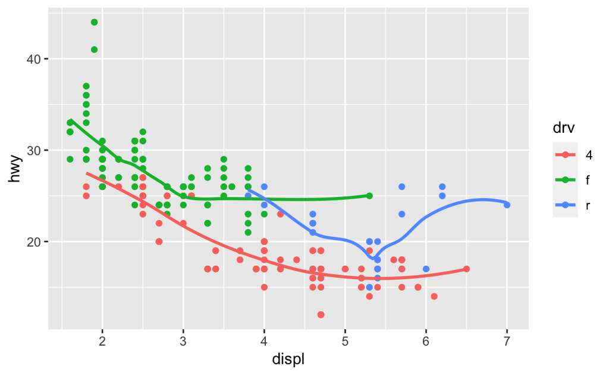

```r
ggplot(data = mpg, mapping = aes(x = displ, y = hwy, color = drv)) +
  geom_point() +
  geom_smooth(se = FALSE)
```

**3:** What does `show.legend = FALSE` do? It removes the legend. What happens if you remove it? Then the legend appears. **Note:** Skip the “Why do you think I used it earlier in the chapter?” question.

**4:** What does the `se` argument to `geom_smooth()` do? It adds upper and lower error limits or confidence bands.

**5:** Will these two graphs look different? Why/why not? No. They display the same data the code is just written in two different ways.

**6:** Recreate the R code necessary to generate the following graphs. **Note:** Enter a separate code chunk for each graph, numbered 1 to 6, starting row-wise at upper left.

1: upper left.

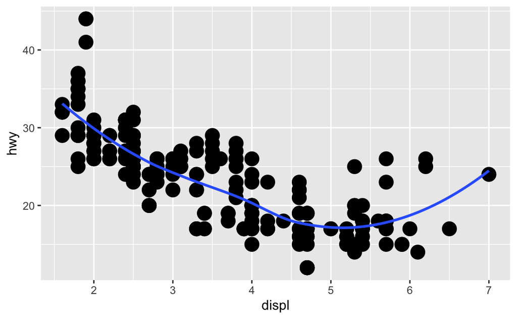

```r
ggplot(data = mpg) +
  geom_point(mapping = aes(x = displ, y = hwy), size=5) +
  geom_smooth(mapping = aes(x = displ, y = hwy), se= FALSE)
```

2: upper right.

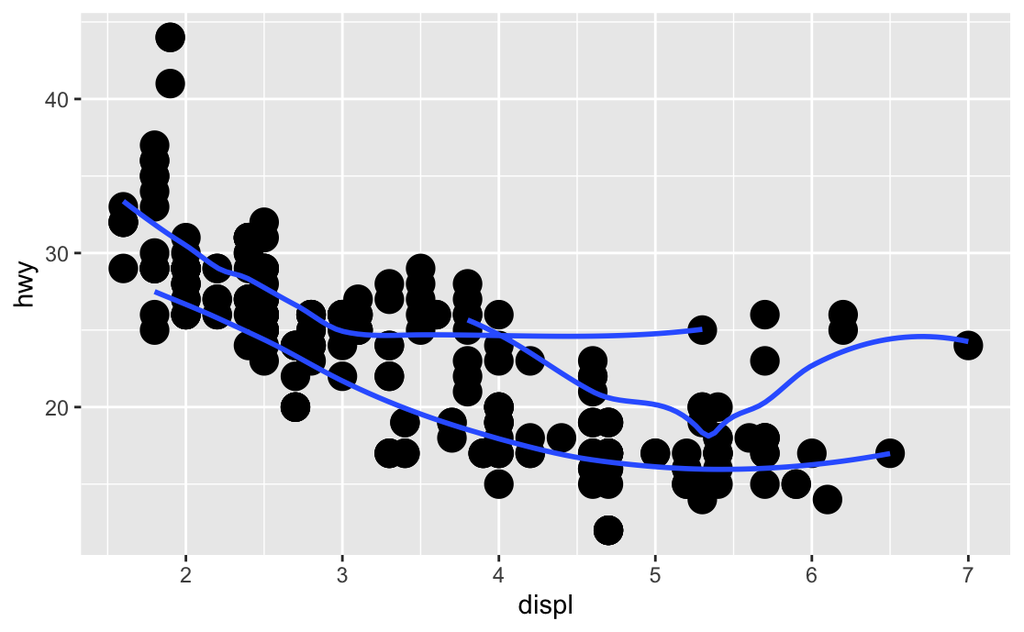

```r
ggplot(data = mpg) +
  geom_point (mapping = aes(x =displ, y = hwy), size=5)+
  geom_smooth(mapping = aes(x = displ, y = hwy, group = drv), se= FALSE)
```

3: middle left.

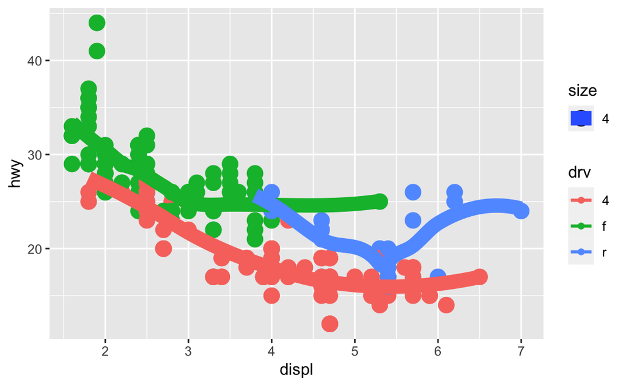

```r
ggplot(data = mpg, mapping = aes(x = displ, y = hwy, color = drv, size= 4)) +
  geom_point() +
  geom_smooth(se = FALSE)
```

4: middle right.

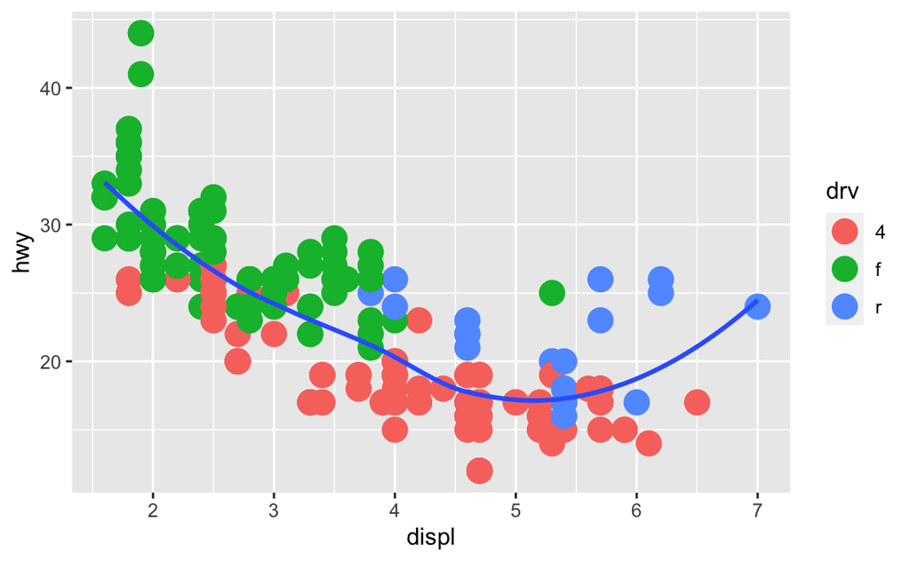

```r
ggplot(data = mpg) +
  geom_point(mapping = aes(x = displ, y = hwy, color= drv), size=5) +
  geom_smooth(mapping = aes(x = displ, y = hwy), se= FALSE)
```

5: lower left.

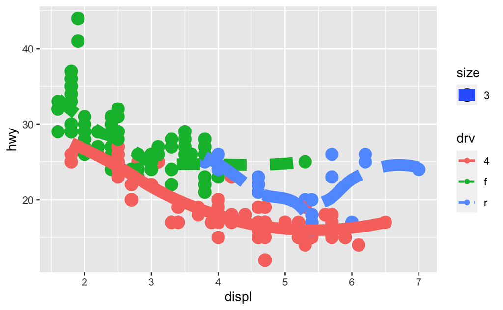

```r
ggplot(data = mpg, mapping = aes(x = displ, y = hwy, color = drv, size= 3)) +
  geom_point() +
  geom_smooth(aes(linetype= drv), se = FALSE)
```

6: lower right. *Hint:* Read the help file for `geom_point`. Use `shape = 21`, `stroke = 2`, and `size = 3`.

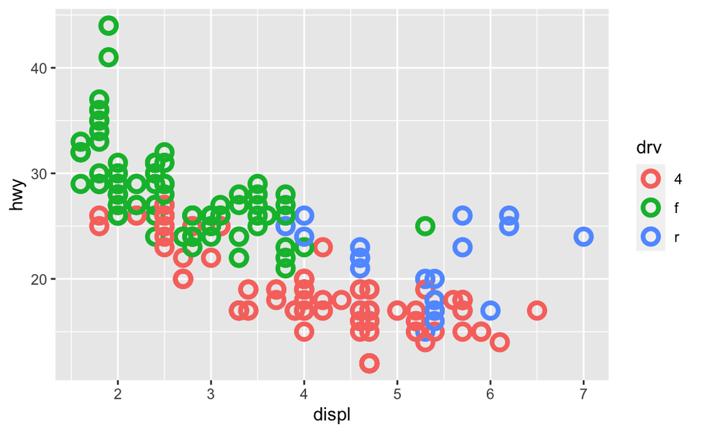

```r
ggplot(data = mpg) +
  geom_point(mapping = aes(x = displ, y = hwy, color= drv), shape= 21, size=3, stroke=2)
```